# week2

Hyungyeong Hong

9/13/2021

# Chapter1. 모델링을 위한 데이터 전처리

## 문제 0. 기본 세팅

```r
source("0번.txt")
```

```
## dummies-1.5.6 provided by Decision Patterns
```

## 문제1. train 데이터 불러온 후 기본 구조 파악, 데이터 개수, 변수 개수, 데이터 형식 파악

```r
train <- fread("train.csv")
```

```r
str(train)
```

```
## Classes 'data.table' and 'data.frame':   2457 obs. of  15 variables:
##  $ 단지코드                                      : chr  "C2483" "C2483" "C2483" "C2483" ...
##  $ 총세대수                                      : int  900 900 900 900 900 545 545 545 545 545 ...
##  $ 임대건물구분                                  : chr  "아파트" "아파트" "아파트" "아파트" ...
##  $ 지역                                          : chr  "경상북도" "경상북도" "경상북도" "경상북도" ...
##  $ 공급유형                                      : chr  "국민임대" "국민임대" "국민임대" "국민임대" ...
##  $ 전용면적                                      : num  51.9 51.9 52 52 59.9 ...
##  $ 전용면적별세대수                              : int  15 41 89 135 86 276 60 20 38 19 ...
##  $ 공가수                                        : int  38 38 38 38 38 17 17 17 17 17 ...
##  $ 자격유형                                      : chr  "A" "A" "A" "A" ...
##  $ 임대보증금                                    : chr  "27304000" "27304000" "27304000" "27304000" ...
##  $ 임대료                                        : chr  "184330" "184330" "184330" "184330" ...
##  $ 도보 10분거리 내 지하철역 수(환승노선 수 반영): int  0 0 0 0 0 0 0 0 0 0 ...
##  $ 도보 10분거리 내 버스정류장 수                : int  3 3 3 3 3 3 3 3 3 3 ...
##  $ 단지내주차면수                                : int  1425 1425 1425 1425 1425 624 624 624 624 624 ...
##  $ 등록차량수                                    : int  1015 1015 1015 1015 1015 205 205 205 205 205 ...
##  - attr(*, ".internal.selfref")=<externalptr>
```

```r
train %>% summarise_all(n_distinct)
```

```
##   단지코드 총세대수 임대건물구분 지역 공급유형 전용면적 전용면적별세대수 공가수
## 1      420      348            2   16       10      640              388     48
##   자격유형 임대보증금 임대료 도보 10분거리 내 지하철역 수(환승노선 수 반영)
## 1       15        876    905                                              5
##   도보 10분거리 내 버스정류장 수 단지내주차면수 등록차량수
## 1                             18            355        352
```

## 문제2. 각 데이터의 칼럼명 확인 및 칼럼명 변경

```r
train %>% colnames
```

```
##  [1] "단지코드"
##  [2] "총세대수"
##  [3] "임대건물구분"
##  [4] "지역"
##  [5] "공급유형"
##  [6] "전용면적"
##  [7] "전용면적별세대수"
##  [8] "공가수"
##  [9] "자격유형"
## [10] "임대보증금"
## [11] "임대료"
## [12] "도보 10분거리 내 지하철역 수(환승노선 수 반영)"
## [13] "도보 10분거리 내 버스정류장 수"
## [14] "단지내주차면수"
## [15] "등록차량수"
```

```r
train  <- train %>% rename("지하철개수" = "도보 10분거리 내 지하철역 수(환승노선 수 반영)",
                 "버스개수" = "도보 10분거리 내 버스정류장 수")
```

```r
test <- fread("test.csv")
test %>% colnames
```

```
##  [1] "단지코드"
##  [2] "총세대수"
##  [3] "임대건물구분"
##  [4] "지역"
##  [5] "공급유형"
##  [6] "전용면적"
##  [7] "전용면적별세대수"
##  [8] "공가수"
##  [9] "자격유형"
## [10] "임대보증금"
## [11] "임대료"
## [12] "도보 10분거리 내 지하철역 수(환승노선 수 반영)"
## [13] "도보 10분거리 내 버스정류장 수"
## [14] "단지내주차면수"
## [15] "등록차량수"
```

```r
test <- test %>% rename("지하철개수" = "도보 10분거리 내 지하철역 수(환승노선 수 반영)",
                 "버스개수" = "도보 10분거리 내 버스정류장 수")
```

## 문제3. ‘임대료’, ’임대보증금’이 문자로 되어 있는 이유를 찾아 수치형으로 변경

- NA 값이 "“, 또는”-"으로 표현되어 있음
- 위의 값들을 NA로 바꿔준 후 해당 칼럼들을 수치형으로 변경

```r
train %>% select(임대료) %>% apply(2, unique) %>% sort
```

```
##   [1] ""        "-"       "100000"  "100260"  "100320"  "100380"  "100690"
##   [8] "100920"  "101080"  "101110"  "101830"  "101920"  "102130"  "102350"
##  [15] "102620"  "102770"  "103250"  "103840"  "103850"  "104000"  "104050"
##  [22] "1042230" "104680"  "104840"  "104930"  "105210"  "105260"  "105280"
##  [29] "1058030" "105870"  "106000"  "106090"  "106530"  "107060"  "107100"
##  [36] "107130"  "107200"  "107530"  "107550"  "107660"  "107680"  "107760"
##  [43] "108080"  "108130"  "108270"  "108800"  "108900"  "109270"  "109400"
##  [50] "109670"  "109840"  "110000"  "110110"  "110500"  "110530"  "110550"
##  [57] "110790"  "110850"  "110960"  "111090"  "111230"  "111470"  "111520"
##  [64] "111740"  "112010"  "112590"  "112790"  "112860"  "113000"  "113560"
##  [71] "113780"  "113800"  "113950"  "114140"  "114650"  "115000"  "115180"
##  [78] "115520"  "116000"  "116090"  "116200"  "116430"  "116950"  "117000"
##  [85] "117060"  "117270"  "117330"  "117620"  "117670"  "117960"  "118000"
##  [92] "118320"  "118580"  "118820"  "118980"  "119000"  "119160"  "119190"
##  [99] "119460"  "119490"  "119860"  "119920"  "120000"  "120060"  "120150"
```

[output cut: 115 more lines]

```r
train %>% select(임대보증금) %>% apply(2, unique) %>% sort
```

```
##   [1] ""          "-"         "10000000"  "100400000" "10043000"  "10060000"
##   [7] "10073000"  "10220000"  "10242000"  "10244000"  "10279000"  "10319000"
##  [13] "10346000"  "10360000"  "10363000"  "10500000"  "10514000"  "10528000"
##  [19] "10602000"  "10638000"  "10651000"  "10692000"  "10718000"  "10803000"
##  [25] "10813000"  "10827000"  "10923000"  "11022000"  "11053000"  "11095000"
##  [31] "11117000"  "11147000"  "11174000"  "11175000"  "11217000"  "11234000"
##  [37] "11269000"  "11303000"  "11346000"  "11380000"  "11397000"  "11414000"
##  [43] "11430000"  "11437000"  "11469000"  "11492000"  "115052000" "11532000"
##  [49] "11533000"  "11542000"  "11574000"  "11620000"  "11661000"  "11682000"
##  [55] "11729000"  "117309000" "11767000"  "11774000"  "11807000"  "11819000"
##  [61] "11858000"  "11869000"  "11983000"  "12015000"  "12026000"  "120611000"
##  [67] "12064000"  "12089000"  "12139000"  "12254000"  "123711000" "12387000"
##  [73] "12392000"  "12461000"  "12483000"  "124970000" "12500000"  "125326000"
##  [79] "12563000"  "12571000"  "12646000"  "12672000"  "12700000"  "12709000"
##  [85] "12720000"  "12728000"  "12800000"  "12864000"  "12881000"  "12906000"
```

[output cut: 131 more lines]

```r
train_na <- which(train$임대료 == "" | train$임대료 == "-")
train$임대료[train_na] <- NA

train_na <- which(train$임대보증금 == "" | train$임대보증금 == "-")
train$임대보증금[train_na] <- NA

train$임대료 <- train$임대료 %>% as.numeric
train$임대보증금 <- train$임대보증금 %>% as.numeric
```

```r
test_na <- which(test$임대료 == "" | test$임대료 == "-")
test$임대료[test_na] <- NA

test_na <- which(test$임대보증금 == "" | test$임대보증금 == "-")
test$임대보증금[test_na] <- NA

test$임대료 <- test$임대료 %>% as.numeric
test$임대보증금 <- test$임대보증금 %>% as.numeric
```

## 문제4. 열별로 NA 개수 확인

```r
train_na_cnt <- apply(train, 2, is.na) %>% colSums %>% sort(decreasing = TRUE) %>% as.data.frame %>% rename("na_cnt" = ".")
train_na_cnt <- train_na_cnt %>% mutate(col_name = rownames(train_na_cnt))
```

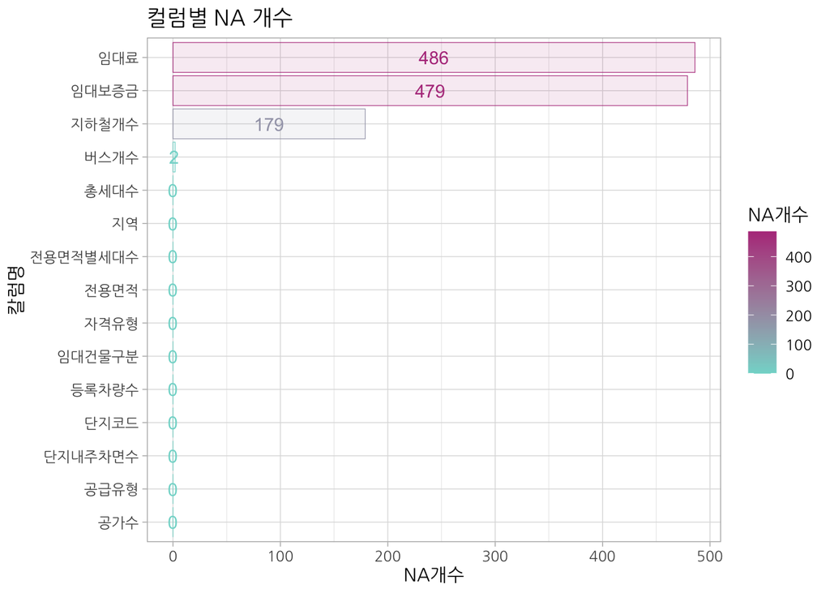

```r
train_na_cnt %>% ggplot() +
  geom_bar(aes(x = reorder(col_name, na_cnt), y = na_cnt, fill = na_cnt, color = na_cnt),
           stat = "identity", alpha = 0.1, cex = 0.2) +
  geom_text(aes(x = reorder(col_name, na_cnt), y = na_cnt/2, label = na_cnt, color = na_cnt)) +
  coord_flip() +
  theme_set(theme_light(base_family='NanumGothic')) +
  scale_fill_gradient(high = "#B43C8A", low = "#81D8D0", guide = "colourbar", aesthetics = "fill", name = "NA개수") +
  scale_color_gradient(high = "#B43C8A", low = "#81D8D0", guide = "colourbar", aesthetics = "color", name = "NA개수") +
  ggtitle("컬럼별 NA 개수") +
  xlab("칼럼명") +
  ylab("NA개수")
```

## 문제 5. 범주형변수를 factor변수로, 정수형변수를 수치형으로 바꾸기

```r
train <- train %>%
  mutate_if(is.integer, as.numeric) %>%
  mutate_if(is.character, as.factor)
```

```r
test <- test %>%
  mutate_if(is.integer, as.numeric) %>%
  mutate_if(is.character, as.factor)
```

## 문제 6. NA 값을 mean imputation

```r
train <- train %>% as.data.frame

for(i in 1:ncol(train)){
  if(is.numeric(train[,i]) == FALSE){
    next
  } else {
    train[,i] <- replace(train[,i], is.na(train[,i]), mean(train[,i], na.rm = TRUE))
  }
}

train <- train %>% as.data.table
```

```r
test <- test %>% as.data.frame

for(i in 1:ncol(test)){
  if(is.numeric(test[,i]) == FALSE){
    next
  } else {
    test[,i] <- replace(test[,i], is.na(test[,i]), mean(test[,i], na.rm = TRUE))
  }
}

test <- test %>% as.data.table
```

## 문제 7. 공급유형 == “장기전세” 이면서 임대료 != 0 확인

```r
which(train$공급유형 == "장기전세" & train$임대료 != 0)
```

```
## [1] 1700 1701 1702 1703 1704 1747 1748
```

```r
test$임대료[which(test$공급유형 == "장기전세" & test$임대료 != 0)] <- 0
```

## 문제 8. 면적당 임대료, 면적당 임대보증금 계산하여 파생변수 생성

```r
train <- train %>% mutate(면적당임대료 = 임대료 / 전용면적, 면적당임대보증금 = 임대보증금 / 전용면적)
test <- test %>% mutate(면적당임대료 = 임대료 / 전용면적, 면적당임대보증금 = 임대보증금 / 전용면적)
```

## 문제 9. 임대료, 임대보증금, 단지코드 삭제

```r
train <- train %>% select(-c(임대료, 임대보증금, 단지코드))
test <- test %>% select(-c(임대료, 임대보증금, 단지코드))
```

# Chapter 2. 랜덤포레스트 및 교차검증

# Chapter 2-1: [Hold-Out]

## 문제 1. 데이터 층화추출을 사용하여 train:validation 7:3 split

```r
set.seed(2728)
train_idx <- createDataPartition(train$등록차량수, p = 0.7, list = FALSE)
train_set <- train[train_idx, ]
valid_set <- train[-train_idx, ]
```

## 문제 2. 랜덤포레스트의 하이퍼파라미터에 대한 설명

- 결정 트리의 개수(ntree): 트리 기반 모델인 랜덤포레스트에서 결정 트리의 개수를 지정하며, 값을 크게 설정할수록 좋은 성능 기대할 수 있지만 무조건적으로 증가시킨다고 항상 성능 향상이 이루어지지는 않는다. 결정 트리의 개수를 늘릴수록 학습 수행 시간이 오래걸린다.
- 트리 분할에 사용할 피처의 개수(mtry): 랜덤포레스트 트리 분할 시 참조할 피처의 개수이다. 즉, 매 모델링마다 사용되는 피처의 개수에 해당한다. 분류 문제의 경우 전체 피처 수의 제곱근만큼, 예측 문제의 경우 전체 피처 수의 1/3 미만을 선택하는 것이 경험적으로 좋은 선택지라고 알려져 있다.
- 이외에도 말단 노드의 최소 크기를 지정하는 nodesize, 말단 노드의 최대 개수를 지정하는 maxnodes가 있다.

## 문제 3. 그리드서치를 위한 데이터프레임 생성

```r
rf_params_HO <- expand.grid(mtry = c(5, 6, 7, 8),
                        ntree = c(200, 300, 400),
                        RMSE = NA)
rf_params_HO
```

```
##    mtry ntree RMSE
## 1     5   200   NA
## 2     6   200   NA
## 3     7   200   NA
## 4     8   200   NA
## 5     5   300   NA
## 6     6   300   NA
## 7     7   300   NA
## 8     8   300   NA
## 9     5   400   NA
## 10    6   400   NA
## 11    7   400   NA
## 12    8   400   NA
```

## 문제 4. Random Forest 모델링

- for loop을 이용하여 등록차량수를 예측하는 랜덤포레스트 모델링 진행
- validation set의 RMSE를 계산하여 rf_params_HO에 값 넣어주기

```r
set.seed(2728)

for(i in 1:nrow(rf_params_HO)){
  rf_model <- randomForest(등록차량수~., train_set,
                              mtry = rf_params_HO$mtry[i],
                              ntree = rf_params_HO$ntree[i])
  rf_yhat = predict(rf_model, newdata = valid_set)
  rf_params_HO$RMSE[i] <- RMSE(rf_yhat, valid_set$등록차량수)
}

rf_params_HO
```

```
##    mtry ntree     RMSE
## 1     5   200 75.43116
## 2     6   200 75.03820
## 3     7   200 74.78597
## 4     8   200 76.02268
## 5     5   300 77.82413
## 6     6   300 74.40328
## 7     7   300 74.67335
## 8     8   300 74.23496
## 9     5   400 76.10203
## 10    6   400 75.07724
## 11    7   400 75.55803
## 12    8   400 73.85076
```

## 문제 5. Hold-Out Random Forest 모델링 결과 시각화

- 해석: mtry가 8일 때는 트리의 개수가 늘어나면 RMSE 값이 줄어들어 성능이 향상된다고 볼 수 있겠으나, 나머지는 딱히.. 플랏을 보니 피처 개수가 늘어날수록 성능이 좋아지는 것 같지만 항상 그런 것은 아닌 듯 하다.. 트리 개수가 적을 때에는 오히려 많은 피처 개수가 해가 되는 것을 확인할 수 있겠다.

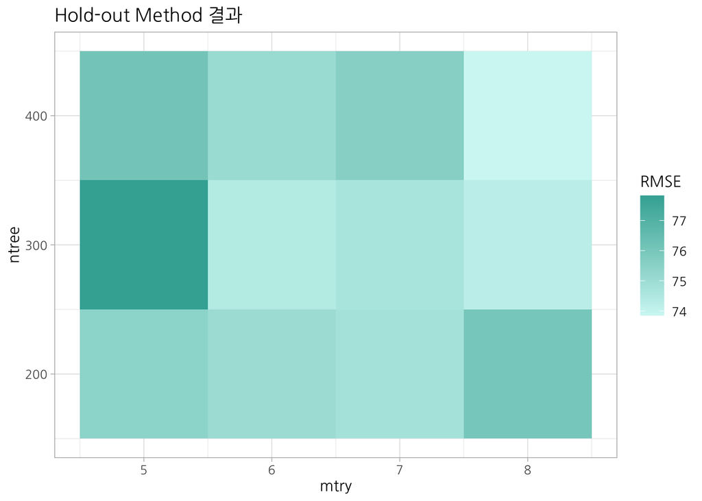

```r
rf_params_HO %>% ggplot(aes(x = mtry, y = ntree, fill = RMSE)) +
  geom_tile() +
  scale_fill_gradient(high = "#3CAEA3", low = "#D2F7F4", aesthetics = "fill",
                      breaks = c(74, 75, 76, 77)) +
  theme_set(theme_light(base_family='NanumGothic')) +
  ggtitle("Hold-out Method 결과")
```

## 문제 6. RMSE가 가장 낮은 하이퍼파라미터 조합을 출력

```r
rf_params_HO %>% filter(RMSE == min(RMSE))
```

```
##   mtry ntree     RMSE
## 1    8   400 73.85076
```

# Chapter 2-2: [5-fold CV]

## 문제 7. 5-fold 교차검증을 위해 층화추출을 사용하여 CV 인덱스 생성

```r
set.seed(2728)
cv <- createFolds(train_set$등록차량수, k = 5)
```

## 문제 8. 그리드서치를 위한 데이터프레임 생성

```r
rf_params_KF <- expand.grid(mtry = c(5, 6, 7, 8),
                        ntree = c(200, 300, 400),
                        RMSE = NA)
rf_params_KF
```

```
##    mtry ntree RMSE
## 1     5   200   NA
## 2     6   200   NA
## 3     7   200   NA
## 4     8   200   NA
## 5     5   300   NA
## 6     6   300   NA
## 7     7   300   NA
## 8     8   300   NA
## 9     5   400   NA
## 10    6   400   NA
## 11    7   400   NA
## 12    8   400   NA
```

## 문제 9. Random Forest 모델링

- 이중 for loop을 활용하여 등록차량수를 예측하는 랜덤포레스트 모델링 진행
- validation set의 RMSE를 계산하여 rf_params_KF에 값 넣어주기

```r
for (i in 1:nrow(rf_params_KF)){
  RMSE_tmp <- NULL

  for(j in 1:5){
    set.seed(2728)

    valid_idx <- cv[[j]]

    cv_train_set <- train[-valid_idx, ]
    cv_valid_set <- train[valid_idx, ]

    rf_model <- randomForest(등록차량수~., cv_train_set,
                              mtry = rf_params_KF$mtry[i],
                              ntree = rf_params_KF$ntree[i])
    rf_yhat <- predict(rf_model, newdata = cv_valid_set)

    RMSE_tmp[j] <- RMSE(rf_yhat, cv_valid_set$등록차량수)
  }
  rf_params_KF$RMSE[i] <- mean(RMSE_tmp)
}

rf_params_KF
```

```
##    mtry ntree     RMSE
## 1     5   200 48.58698
## 2     6   200 45.40683
## 3     7   200 44.61123
## 4     8   200 42.14889
## 5     5   300 48.04447
## 6     6   300 45.38159
## 7     7   300 44.61501
## 8     8   300 42.14046
## 9     5   400 48.00362
## 10    6   400 45.28671
## 11    7   400 44.43782
## 12    8   400 41.97270
```

## 문제 10. 5-Out CV Random Forest 모델링 결과 시각화

- 해석: 참조하는 피처의 개수가 많이질수록 RMSE 값이 작은 것을 확인할 수 있다.

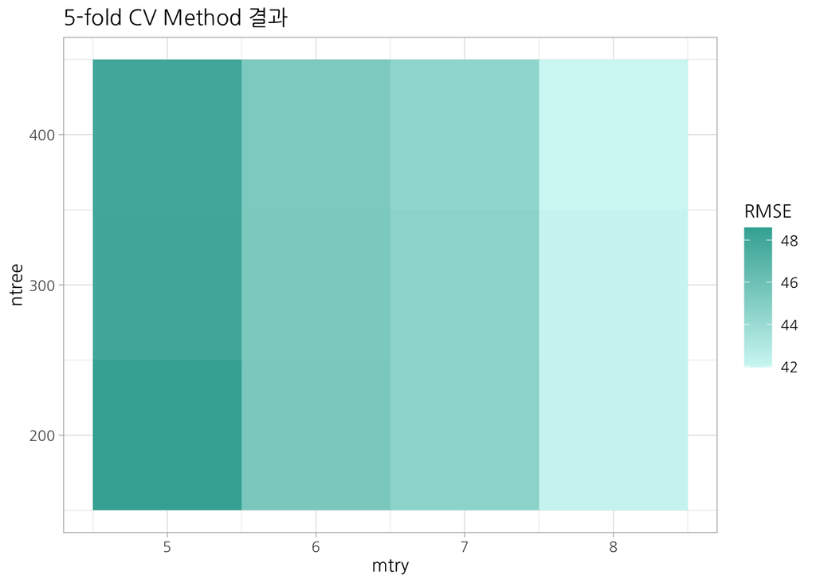

```r
rf_params_KF %>% ggplot(aes(x = mtry, y = ntree, fill = RMSE)) +
  geom_tile() +
  scale_fill_gradient(high = "#3CAEA3", low = "#D2F7F4", aesthetics = "fill") +
  theme_set(theme_light(base_family='NanumGothic')) +
  ggtitle("5-fold CV Method 결과")
```

## 문제 11. RMSE가 가장 낮은 하이퍼파라미터 조합을 출력

```r
rf_params_KF %>% filter(RMSE == min(RMSE))
```

```
##   mtry ntree    RMSE
## 1    8   400 41.9727
```

# Chapter 2-3. 결과비교

## 문제 12. Hold-out 튜닝 결과와 5-fold CV 튜닝 결과 비교하여 시각화 및 해석

```r
rf_params_HO$method <- "Hold-out"
rf_params_KF$method <- "5-fold CV"

rf_result <- rbind(rf_params_HO, rf_params_KF)

for(i in 1:24){
  rf_result$param_idx[i] <- paste0("param", i)
}

rf_result
```

```
##    mtry ntree     RMSE    method param_idx
## 1     5   200 75.43116  Hold-out    param1
## 2     6   200 75.03820  Hold-out    param2
## 3     7   200 74.78597  Hold-out    param3
## 4     8   200 76.02268  Hold-out    param4
## 5     5   300 77.82413  Hold-out    param5
## 6     6   300 74.40328  Hold-out    param6
## 7     7   300 74.67335  Hold-out    param7
## 8     8   300 74.23496  Hold-out    param8
## 9     5   400 76.10203  Hold-out    param9
## 10    6   400 75.07724  Hold-out   param10
## 11    7   400 75.55803  Hold-out   param11
## 12    8   400 73.85076  Hold-out   param12
## 13    5   200 48.58698 5-fold CV   param13
## 14    6   200 45.40683 5-fold CV   param14
## 15    7   200 44.61123 5-fold CV   param15
## 16    8   200 42.14889 5-fold CV   param16
## 17    5   300 48.04447 5-fold CV   param17
## 18    6   300 45.38159 5-fold CV   param18
## 19    7   300 44.61501 5-fold CV   param19
## 20    8   300 42.14046 5-fold CV   param20
## 21    5   400 48.00362 5-fold CV   param21
## 22    6   400 45.28671 5-fold CV   param22
## 23    7   400 44.43782 5-fold CV   param23
## 24    8   400 41.97270 5-fold CV   param24
```

- 해석: Hold-Out에 비해 5-fold CV를 이용하여 튜닝한 결과가 더 좋은 것을 확인할 수 있다. Hold-out의 경우 데이터셋의 크기가 커야 그나마 좋은 성능을 내는 것으로 알고 있는데, 우리의 데이터셋은 row 수가 많지 않아 좋은 성능을 기대할 수 없었을 것이다. 또한 한번 split을 하면 validation set이 고정되어 있는 hold-out과는 달리 k-fold CV는 데이터셋을 k개의 그룹으로 나눈 후 각 그룹이 한번씩 validation set이 되기 때문에 unseen data에 대한 더 나은 지표를 제공할 수 있다.

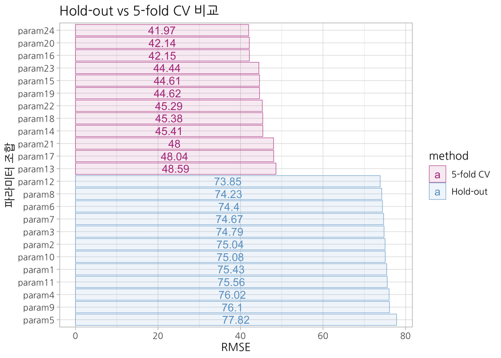

```r
rf_result %>% ggplot() +
  geom_bar(aes(x = reorder(param_idx, -RMSE), y = RMSE, fill = method, color = method),
           stat = "identity",  alpha = 0.1, cex = 0.2) +
  geom_text(aes(x = reorder(param_idx, -RMSE), y = RMSE/2, label = round(RMSE, 2), color = method)) +
  coord_flip() +
  scale_fill_manual(values = c("Hold-out" = "#6AA2CD", "5-fold CV" = "#B43C8A")) +
  scale_color_manual(values = c("Hold-out" = "#6AA2CD", "5-fold CV" = "#B43C8A")) +
  theme_set(theme_light(base_family='NanumGothic')) +
  ggtitle("Hold-out vs 5-fold CV 비교") +
  xlab("파라미터 조합") +
  ylab("RMSE")
```

## 문제 13. 랜덤포레스트에서 importance 계산이 어떻게 되는가?

- 각각의 bootstrap sample에서 OOB(out of bag) samples를 구할 수 있는데, 이 때 OOB samples의 경우 model building에 사용되지 않으므로 validation set과 같이 이용될 수 있다.
- 따라서, OOB samples를 모델에 넣어주고, mse(error) 값을 구해준다.
- 그 다음, OOB sample에서 특정 변수에 대한 permutation을 시행한 후 이를 모델에 넣어주어 mse(error)값을 구한다.
- OOB samples permutation 전후의 error 값에 대한 차이를 구한다.
- 따라서, importance는 해당 변수가 랜덤으로 분포되었을 때, 어느 정도 성능이 떨어지는지를 통해 나타난다.

## 문제 14. 가장 좋게 나온 하이퍼파라미터 조합으로 학습

- 가장 좋게 나온 하이퍼파라미터 조합에 대하여 전체 train에 대하여 학습

```r
rf_best_param <- rf_result %>% filter(param_idx == "param24")
rf_best_param
```

```
##   mtry ntree    RMSE    method param_idx
## 1    8   400 41.9727 5-fold CV   param24
```

```r
rf_model <- randomForest(등록차량수~., train,
                              mtry = rf_best_param$mtry,
                              ntree = rf_best_param$ntree)
```

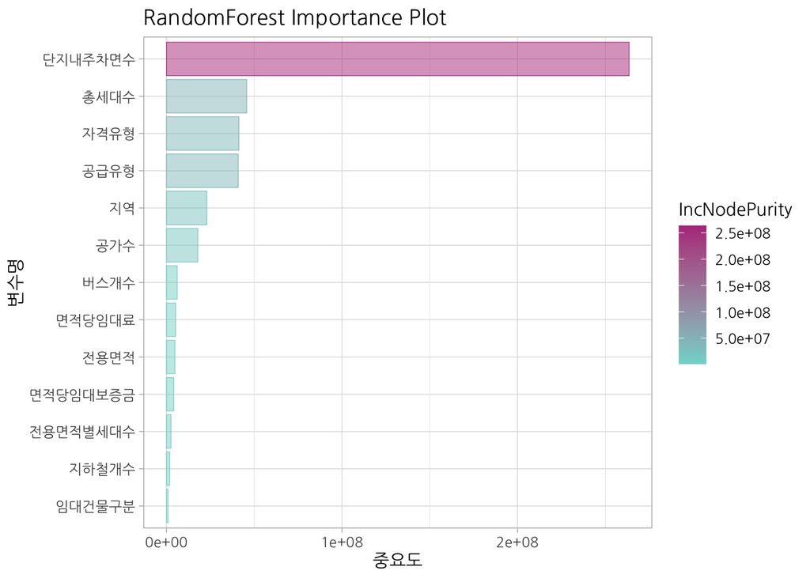

```r
rf_importance %>% ggplot(aes(x = reorder(변수명, IncNodePurity), y = IncNodePurity, fill = IncNodePurity, color = IncNodePurity)) +
  geom_bar(stat = "identity", alpha = 0.5, cex = 0.2) +
  coord_flip() +
  scale_fill_gradient(high = "#B43C8A", low = "#81D8D0", aesthetics = "fill") +
  scale_color_gradient(high = "#B43C8A", low = "#81D8D0", aesthetics = "color") +
  theme_set(theme_light(base_family='NanumGothic')) +
  ggtitle("RandomForest Importance Plot") +
  xlab("변수명") +
  ylab("중요도")
```

# Chapter 3. XGBoost

## 문제 1. 범주형 변수에 대한 one-hot encoding

```r
onehot <- dummyVars(" ~.", data = train)
train_onehot <- predict(onehot, newdata = train) %>% as.data.frame
```

## 문제 2. XGBoost의 하이퍼파라미터에 대한 설명

- eta: GBM의 학습률에 해당하며, 0에서 1 사이의 값을 갖는다.
- nrounds: 약한 학습기의 개수에 해당한다.
- min_child_weight: 트리에서 추가적으로 가지를 나눌지를 결정하기 위해 필요한 데이터들의 weight의 총합에 해당하며, 이 값이 클수록 분할이 자제되어 과적합 제어 용도로 쓰인다.
- max_depth: 트리의 최대 깊이를 나타낸다. 값이 클수록 특정 피처에 특화되어 조건이 만들어지므로 과적합 가능성이 높아진다.
- subsample: 트리가 커져 과적합이 발생하는 것을 제어하기 위해 데이터 샘플링 비율을 지정한다.
- colsample_bytree: 트리 생성에 필요한 피터를 임의로 샘플링 할 때 이용한다. 피처 개수가 많을 경우 과적합 제어에 이용한다.
- 이외에도 alpha, lambda 값을 통해 과적합을 제어할 수 있으며, scale_pos_weight를 통해 비대칭 클래스로 구성된 데이터 세트의 균형을 유지해 줄 수도 있다. 추가적으로 early stopping 설정을 통해서도 과적합을 방지할 수 있다.

## 문제 3. 랜덤 서치 대상 파라미터 샘플링

```r
set.seed(2728)

max_depth <- sample(4:10, 12, replace = TRUE)
min_child_weight <- sample(4:10, 12, replace = TRUE)
subsample <-runif(min = 0.5, max = 1, n = 12)
colsample_bytree <- runif(min = 0.5, max = 1, n = 12)
```

## 문제 4. XGBoost 회귀모델링: 5-fold CV 사용

```r
xgb_result <- data.frame(iterations = 1:12,
                      max_depth = max_depth,
                      min_child_weight = min_child_weight,
                      subsample = subsample,
                      colsample_bytree = colsample_bytree,
                      RMSE = NA)

for(i in 1:12){
  RMSE_tmp <- NULL

  for(j in 1:5){
    set.seed(2728)
    valid_idx <- cv[[j]]

    cv_train_set <- xgb.DMatrix(data = as.matrix(train_onehot[-valid_idx, -51]), label = as.matrix(train_onehot[-valid_idx, 51]))
    cv_valid_set <- xgb.DMatrix(data = as.matrix(train_onehot[valid_idx, -51]), label = as.matrix(train_onehot[valid_idx, 51]))

    xgb_model <- xgboost(data = cv_train_set,
                         max_depth = max_depth[i],
                         min_child_weight = min_child_weight[i],
                         subsample = subsample[i],
                         colsample_bytree = colsample_bytree[i],
                         eta = 0.01, nrounds = 1000, early_stopping_rounds = 0.05*1000, print_every_n = 50)

    xgb_yhat <- predict(xgb_model, newdata = cv_valid_set)
    RMSE_tmp[j] <- RMSE(xgb_yhat, train_onehot[valid_idx, 51])
  }
  xgb_result$RMSE[i] <- mean(RMSE_tmp)
}
```

[output not shown]

[output cut: 65 more lines]

[output not shown]

## 문제 5. 결과 시각화 및 최고 성능을 내는 하이퍼파라미터 조합 도출

- 결과 시각화

```r
for(i in 1:12){
  xgb_result$param_idx[i] <- paste0("param", i)
}
xgb_result
```

```
##    iterations max_depth min_child_weight subsample colsample_bytree     RMSE
## 1           1         7                5 0.9215745        0.7656291 48.74787
## 2           2        10                5 0.7620911        0.9734533 38.55486
## 3           3         6                4 0.6932826        0.5291200 62.04640
## 4           4         9                6 0.5118525        0.8745289 49.79977
## 5           5        10                6 0.7354151        0.6907682 43.88502
## 6           6         6               10 0.7528610        0.7250934 65.04802
## 7           7         8                8 0.6531129        0.7132501 53.53349
## 8           8         8                9 0.7658404        0.6000174 54.13780
## 9           9         9                6 0.9487111        0.6509074 43.01625
## 10         10         7                4 0.7975257        0.6623642 49.06717
## 11         11         6                8 0.5377452        0.8565005 65.67851
## 12         12         6                7 0.7855585        0.6128792 62.69080
##    param_idx
## 1     param1
## 2     param2
## 3     param3
## 4     param4
## 5     param5
## 6     param6
## 7     param7
## 8     param8
## 9     param9
## 10   param10
## 11   param11
## 12   param12
```

- 최고의 성능을 내는 하이퍼파라미터 조합

```r
xgb_best_param <- xgb_result %>% filter(RMSE == min(RMSE))
```

- 결과 시각화

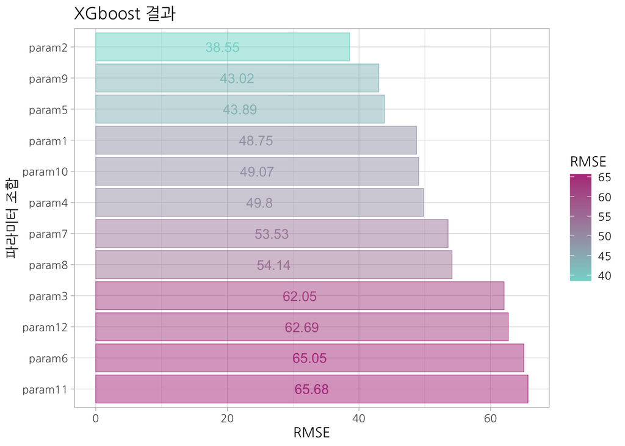

```r
xgb_result %>% ggplot() +
  geom_bar(aes(x = reorder(param_idx, -RMSE), y = RMSE, fill = RMSE, color = RMSE),
           stat = "identity",  alpha = 0.5, cex = 0.2) +
  geom_text(aes(x = reorder(param_idx, -RMSE), y = RMSE/2, label = round(RMSE, 2), color = RMSE)) +
  coord_flip() +
  scale_fill_gradient(high = "#B43C8A", low = "#81D8D0", aesthetics = "fill") +
  scale_color_gradient(high = "#B43C8A", low = "#81D8D0", aesthetics = "color") +
  theme_set(theme_light(base_family='NanumGothic')) +
  ggtitle("XGboost 결과") +
  xlab("파라미터 조합") +
  ylab("RMSE")
```

- 그리드서치(Grid Search): 그리드서치에서는 각 하이퍼파라미터 조합이 grid로 설정되고, 이떄의 각 하이퍼파라미터 조합을 이용하여 모델을 학습시킨다. 가능한 모든 하이퍼파라미터의 조합에 대해 계산을 진행하므로 비효율적이다. 또한, 단순히 각 조합을 비교하는 것으로 grid search에서 가장 좋은 성능을 내더라도 최적의 파라미터는 아닐 가능성이 존재한다.
- 랜덤서치(Random Search): 핸덤서치에서는 그리드서치와는 달리 탐색할 하이퍼파라미터의 값들이 범위로 주어지고, 해당 범위에서 하이퍼파라미터 값들이 랜덤으로 선택된다.
- 랜덤서치가 가지는 장점과 단점: 랜덤서치의 경우 불필요한 탐색 횟수를 줄여 그리드서치에 비해 효율적이고, 시간도 적게 걸린다. 또한, 범위 내에서 랜덤으로 파라미터를 탐색하기 때문에 최적의 파라미터를 찾을 가능성이 더 높다. 그러나, 하이퍼파라미터 범위가 너무 넓을 경우 일반화된 결과를 기대하기 어려우며, 범위 내에서 랜덤하게 하이퍼파라미터를 뽑아내므로 시드 고정을 하지 않으면 결과가 매번 달라지게 된다. 또한, 그리드 서치와 같이 여전히 최적화 파라미터를 찾지 못할 가능성이 존재한다.

# Chapter 4. 비교

## 문제 1. test set 불러온 후 train set과 동일하게 전처리

```r
test <- fread("test.csv")

test <- test %>% rename("지하철개수" = "도보 10분거리 내 지하철역 수(환승노선 수 반영)",
                 "버스개수" = "도보 10분거리 내 버스정류장 수")

test_na <- which(test$임대료 == "" | test$임대료 == "-")
test$임대료[test_na] <- NA

test_na <- which(test$임대보증금 == "" | test$임대보증금 == "-")
test$임대보증금[test_na] <- NA

test$임대료 <- test$임대료 %>% as.numeric
test$임대보증금 <- test$임대보증금 %>% as.numeric

test <- test %>%
  mutate_if(is.integer, as.numeric) %>%
  mutate_if(is.character, as.factor)

test <- test %>% as.data.frame

for(i in 1:ncol(test)){
  if(is.numeric(test[,i]) == FALSE){
    next
  } else {
    test[,i] <- replace(test[,i], is.na(test[,i]), mean(test[,i], na.rm = TRUE))
  }
}

test <- test %>% as.data.table

test$임대료[which(test$공급유형 == "장기전세" & test$임대료 != 0)] <- 0

test <- test %>% mutate(면적당임대료 = 임대료 / 전용면적, 면적당임대보증금 = 임대보증금 / 전용면적)

test <- test %>% select(-c(임대료, 임대보증금, 단지코드))
```

## 문제 2. RandomForest

```r
set.seed(2728)
rf_model <- randomForest(등록차량수~., train,
                              mtry = rf_best_param$mtry,
                              ntree = rf_best_param$ntree)
rf_yhat <- predict(rf_model, test)
rf_RMSE <- RMSE(rf_yhat, test$등록차량수)
```

## 문제 3. XGBoost

- XGBoost 모델링을 위해 test set에 대한 one-hot-encoding 시행

```r
onehot <- dummyVars(" ~.", data = test)
test_onehot <- predict(onehot, newdata = test) %>% as.data.frame
```

```r
xgb_best_param
```

```
##   iterations max_depth min_child_weight subsample colsample_bytree     RMSE
## 1          2        10                5 0.7620911        0.9734533 38.55486
##   param_idx
## 1    param2
```

```r
set.seed(2728)
xgb_train <- xgb.DMatrix(data = as.matrix(train_onehot[, -51]), label = as.matrix(train_onehot[, 51]))
xgb_test <- xgb.DMatrix(data = as.matrix(test_onehot[, -51]), label = as.matrix(test_onehot[, 51]))

xgb_model <- xgboost(data = xgb_train,
                     max_depth = xgb_best_param$max_depth,
                     min_child_weight = xgb_best_param$min_child_weight,
                     subsample = xgb_best_param$subsample,
                     colsample_bytree = xgb_best_param$colsample_bytree,
                     eta = 0.01, nrounds = 1000, early_stopping_rounds = 0.05*1000, print_every_n = 50)
```

```
## Will train until train_rmse hasn't improved in 50 rounds.
##
```

```r
xgb_yhat <- predict(xgb_model, newdata = xgb_test)
xgb_RMSE <- RMSE(xgb_yhat, test_onehot[,51])
```

## 문제 4. 2개의 모델링 결과 시각화 및 해석

- 랜덤포레스트에 비해 XGBoost가 RMSE값이 더 작아 더 좋은 성능을 보임을 확인할 수 있다. 그리드서치를 이용하여 하이퍼파라미터 튜닝을 진행한 랜덤포레스트와는 다르게 XGBoost의 경우 랜덤서치를 이용하여 하이퍼파라미터 튜닝을 진행했기 때문에 최적의 파라미터에 더 가까웠을 가능성이 있겠다.

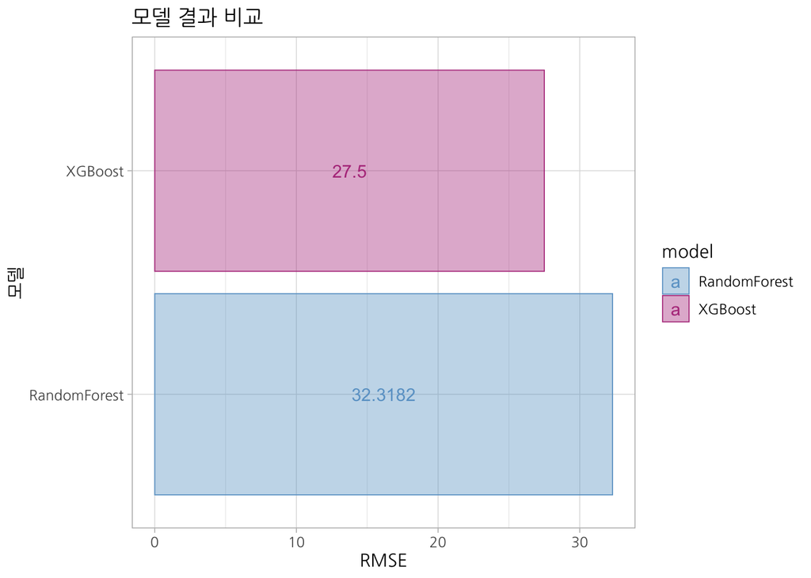

```r
model_result <- data.frame(model = c("XGBoost", "RandomForest"), RMSE = c(xgb_RMSE, rf_RMSE))

model_result %>% ggplot(aes(x = model, y = RMSE, fill = model, color = model)) +
  geom_bar(aes(x = model, y = RMSE, fill = model, color = model), stat = "identity", alpha = 0.4, cex = 0.3) +
  geom_text(aes(x = model, y = RMSE/2, label = round(RMSE, 4), color = model)) +
  coord_flip() +
  scale_fill_manual(values = c("RandomForest" = "#6AA2CD", "XGBoost" = "#B43C8A")) +
  scale_color_manual(values = c("RandomForest" = "#6AA2CD", "XGBoost" = "#B43C8A")) +
  theme_set(theme_light(base_family='NanumGothic')) +
  ggtitle("모델 결과 비교") +
  xlab("모델") +
  ylab("RMSE")
```